# Basic model of evolutionary rescue in discrete time

05.11.2026

# Abstract

Evolutionary rescue occurs when an initially maladapted population adapts to a severe environmental change via advantageous mutations before going extinct. While theoretical models often treat populations as homogeneous, real populations feature distinct age structures. This project extends a standard discrete-time model of evolutionary rescue to include juvenile and adult life stages. We simulate population trajectories to evaluate how mutations affecting stage-specific survival rates or reproduction rates influence the probability of evolutionary rescue.

# Introduction

When a sudden environmental change occurs, a population may become unfit and experience rapid decline[citation]. If a beneficial mutation arises and spreads fast enough to outcompete the declining wild type, the population can avoid extinction—a process known as evolutionary rescue[citation].

While basic models of evolutionary rescue are well-established, they rarely account for the demographic realities of stage-structured populations. Our research question is: **How does age structure (specifically, juvenile versus adult life stages) influence the probability of evolutionary rescue when mutations provide stage-specific advantages?** This is an interesting question because in natural populations, environmental stressors and genetic adaptations often disproportionately affect specific life stages. By separating survival and reproduction into juvenile and adult phases, we can investigate whether a survival advantage in adults is more effective at driving evolutionary rescue than a survival advantage in juveniles, or how these compare to reproductive advantages.

# Model & Methods

## Model Sketch and Life Cycle

We model a haploid population with two distinct life stages: juveniles and adults. The life cycle proceeds in discrete generations as follows:

1. **Reproduction:** Adults reproduce, producing a Poisson-distributed number of juvenile offspring.
2. **Mutation:** A proportion of wild-type offspring mutate into the beneficial mutant genotype.
3. **Maturation & Survival:** Juveniles survive to become adults in the next generation based on a juvenile survival probability. Existing adults survive to the next generation based on an adult survival probability.

## Parameters and Variables

The model relies on the following parameters and variables:

| Parameter / Variable | Description |
| --- | --- |
| `N_j0` / `N_a0` | Initial population size of wild-type juveniles / adults |
| `N_j0M` / `N_a0M` | Initial population size of mutant juveniles / adults |
| `R_a` / `R_aM` | Reproduction rate (offspring per individual) of wild-type / mutant adults |
| `S_j` / `S_jM` | Survival probability of wild-type / mutant juveniles |
| `S_a` / `S_aM` | Survival probability of wild-type / mutant adults |
| `mu` | Mutation rate per generation |
| `t_max` | Maximum number of generations to simulate |

#### installing packages for plotting (currently put as comments for knitting)

```r
#install.packages("dplyr")
#install.packages("tidyr")
#install.packages("ggplot2")
set.seed(123)
```

## Simulating a Single Generation

The following code chunk defines the function to simulate a single generation of the population. It calculates the newly mutated number of juveniles as the number adults times the reproduction rate and mutation rate. The number of WT juveniles is calculated by multiplying the number of adults in the previous generation with their reproduction and substracting the number of newly mutated juveniles. Also the new number of both mutant and WT adults is calculated by adding the number of adults / juveniles of the previous generation which are both multiplied by their corresponding survival rates. Due to an error occuring because some values were negative we put the max() at all places to avoid this, even if it may be unnecessary.

```r
# Simulate WT-Population without any mutations and stochasticity
simulate_one_gen <- function(N_j0, N_a0,N_j0M, N_a0M, R_a, R_aM, S_j, S_jM, S_a, S_aM, mu){

  N_a0 <- max(N_a0, 0)

  New_jtM <- max(rpois(1, N_a0 * mu * R_a), 0) # Calculate new mutant juveniles

  N_jt <- max(rpois(1, R_a * N_a0) - New_jtM, 0) # Calculate number of WT juveniles

  N_at <- max(rpois(1, S_j * N_j0 + S_a * N_a0), 0) # Calculate number of WT adults

  N_jtM <- max(rpois(1, N_a0M * R_aM) + New_jtM, 0) # Calculate number of total mutant juveniles

  N_atM <- max (rpois(1, N_j0M * S_jM + S_aM * N_a0M), 0) # Calculate number of mutant adults

  # return the number of individuals for each combination of age class and haplotype
  return(c(N_jt, N_at, N_jtM, N_atM))
}
```

## Simulate a population trajectory

To track the population over time until it either goes extinct or undergoes evolutionary rescue, we loop the single-generation function. This chunk defines the trajectory function and sets a break condition to stop the simulation early if the population recovers (exceeds some multiple of the initial size) or goes completely extinct.

```r
# define function to simulate population trajectory
simulate_pop <- function(N_j0, N_a0,N_j0M, N_a0M, R_a, R_aM, S_j, S_jM, S_a, S_aM, mu, t_max) {

  # Create vector in which all generations are saved + vector in which current generation is saved
  pop_vector <- c(N_j0, N_a0, N_j0M, N_a0M)
  pop_new <- c(N_j0, N_a0, N_j0M, N_a0M)

  # run the simulation until generation t_max
  for (i in 1:t_max+1) {

    # define pop_new as the output of simulate_one_gen with the number of individuals from the generation before
    pop_new <- simulate_one_gen(pop_new[1],pop_new[2],pop_new[3],pop_new[4], R_a,R_aM, S_j, S_jM, S_a, S_aM, mu)

    # add the new numbers of individuals to the output vector
    pop_vector <- rbind(pop_vector,pop_new)

    # condition to stop the simulation before t_max: either the population exceeds x times the original population   size, or it goes extinct
    if ( (pop_new[1]+pop_new[2]+ pop_new[3]+pop_new[4] >=3*(N_j0+ N_a0 + N_j0M+ N_a0M)) | (pop_new[1]+pop_new[2]+ pop_new[3]+pop_new[4]==0)) break }

  # add row and column names
  colnames(pop_vector) <- c("AC1", "AC2", "AC1M", "AC2M")
  rownames(pop_vector) <- (0:t_max)[1:length(pop_vector[,1])]

  # in the end we want the population trajectory, which is in "pop_vector"
  return(pop_vector)
}
```

## Comparing Juvenile vs. Adult Survival Rate Increase in Mutants

To determine whether the life stage at which adaptation occurs influences the likelihood of evolutionary rescue, we compare scenarios where the beneficial mutation increases either juvenile survival ($S_j \rightarrow S_{jM}$) or adult survival ($S_a\rightarrow S_{aM}$). For evolutionary rescue to be necessary and possible, the wild-type population must have a sub-critical growth rate ($\lambda < 1$), whereas the mutant must be capable of achieving a supercritical growth rate ($\lambda > 1$).

We set baseline wild-type survival parameters ($S_j = 0.2$, $S_a = 0.5$) and adult reproduction ($R_a = 2$). We then systematically vary a selection coefficient multiplier (`s_coeff`) from 1.0 to 2.0 in steps of 0.05. For each parameter combination, we run 1,000 stochastic replicate simulations up to $t_{\text{max}} = 1000$ generations. A simulation is scored as rescued if the minimum recorded total population size does not drop to zero. From these runs, we calculate the empirical rescue probability across the range of absolute survival rates for both life stages to compare their relative impact on evolutionary rescue.

```r
# define the parameters under which we want to simulate the population trajectory
N_j0 <-50
N_a0 <- 50
N_j0M <- 0
N_a0M <- 0
R_a <- 2
R_aM <- 2
S_j <- 0.2
S_a <- 0.5
mu <- 0.01
t_max <- 1000



# determine how often to run the simulation for each set of parameters / how many replicates we want
no_replicates <- 1000

# initialize data table - where to collect the results
data_table_survcompare <- c()

# Doing a parameter sweep:
# We want all s_coeff (= relative increase in survival) for juveniles and adults)


for (selection_on_jM in c(TRUE,FALSE)){
  for (s_coeff in seq(1, 2, 0.05)){ #s_coeff from first number to second number in steps of third number
    S_j <- 0.2 # survival probability of WT juveniles

    # if selection_on_jM is true (= survival of juvenile Mutants is increased) the survival of the juvenile mutants is calculated by multiplying the WT juvenile survival with the S_coeff. If not its the same es the WT juvenile survival
    S_jM <- S_j * ifelse(selection_on_jM, s_coeff, 1) # survival probability of mutant juveniles

    S_a <- 0.5 # survival probability of WT adults

    # same as above with S_jM just the other way around for the adult mutants survival
    S_aM <- S_a * ifelse(selection_on_jM, 1, s_coeff) # survival probability of mutant adults


    i<-1
    repeat {
      # increase counter by one
      i<-i+1
      # run the simulation (population trajectory) once with the corresponding parameters
      one_run <- simulate_pop(N_j0, N_a0,N_j0M, N_a0M, R_a, R_aM, S_j, S_jM, S_a, S_aM, mu, t_max)
      # determine total population sizes
      total_size <- one_run[,1]+one_run[,2] +one_run[,3]+one_run[,4]
      # determine minimum population size through the whole simulation
      min_size <- min(total_size)
      # determine (first) generation at which this population size occurred
      min_gen <- as.numeric(which(total_size==min_size)[1])
      #defining absolute survival for each run
      S_abs <- ifelse(selection_on_jM, S_jM, S_aM)
      # enter the data into the table
      data_table_survcompare <- rbind(data_table_survcompare,c(s_coeff,S_abs,ifelse(selection_on_jM, "on_juveniles", "on_adults"),min_gen,min_size)) # note that we add the varying parameters (decay rate and selection coefficient) to the table too
      # stop the repeated computation after no_replicates times
      if(i>no_replicates) break
    }
  }
}

# define column names of data table
colnames(data_table_survcompare) <- c("S_coeff","S_absolute","ac_s","min_gen","no_min")
# show the first lines of the output


#making the matrix a table and making some values numeric to be able to calculate with them
df <- as.data.frame(data_table_survcompare)
df$S_abs <- as.numeric(df$S_abs)
df$min_gen <- as.numeric(df$min_gen)
df$no_min <- as.numeric(df$no_min)
df$rescued <- df$no_min != 0

#try if the basic principle of getting the rescue-probability works
df_filter <- df[df$s_coeff == 1 & df$ac_s == "on_juveniles",]

#creating an empty table to put the stuff to plot in
plot_table <- c()

# creating the
for(x in unique(df$ac_s)){
 for(s in unique(df$S_abs)){
  df_filter <- df[df$S_abs == s & df$ac_s == x,]
  plot_table <- rbind(plot_table, c(mean(df_filter$rescued), x, s))
 }
}

colnames(plot_table) <- c("rescue prob.","ac_s","S_absolute")
```

## Comparing Mutated Reproduction Rate vs. Mutated Survival Rate

Mutations in nature can alter reproductive output, survival probabilities, or both simultaneously. To understand how these two life-history traits interact in driving rescue dynamics, we evaluate combinations of increased adult fecundity ($R_a \rightarrow R_{aM}$) and stage survival rates ($S_a \rightarrow S_{aM}$ and $S_j \rightarrow S_{jM}$).

```r
# --- 1. BASE PARAMETERS ---
N_j0 <-50
N_a0 <- 50
N_j0M <- 0
N_a0M <- 0
R_a <- 2
S_j <- 0.2
S_a <- 0.5
mu <- 0.01
t_max <- 1000



# Simulation repetitions
no_replicates <- 1000

#data table initializing
data_table <- c()

# loop over reproduction selection
for (repro_val in seq(1,1.5,0.05)) {

  # loop over survival selection
  for (surv_val in seq(1, 1.2, 0.02)) {

    # Calculate modified rates based on current loop values
    current_R_aM <- R_a * repro_val
    current_S_aM <- S_a * surv_val
    current_S_jM <- S_j * surv_val

    # reset counter for replicates
    i <- 1

    repeat {
      # run the simulation once with the modified parameters
      one_run <- simulate_pop(N_j0, N_a0, N_j0M, N_a0M,
                              R_a, current_R_aM,
                              S_j, current_S_jM,
                              S_a, current_S_aM,
                              mu, t_max)

      # determine total population sizes
      total_size <- one_run[,1] + one_run[,2] + one_run[,3] + one_run[,4]

      # determine minimum population size
      min_size <- min(total_size)


      # determine (first) generation at which this population size occurred
      min_gen <- as.numeric(which(total_size == min_size)[1])



      # enter the data into the table
      data_table <- rbind(data_table, c(repro_val, surv_val, min_gen, min_size, current_R_aM,current_S_aM,current_S_jM))

      # stop the repeated computation after no_replicates times
      if (i >= no_replicates) break

      # increase counter by one
      i <- i + 1
    }
  }
}

# define column names of data table
colnames(data_table) <- c("repro_multiplier", "surv_multiplier", "min_gen", "min_size", "Current_R", "Current_S_Adults","Current_S_Juveniles" )

# Convert to data frame
data_table_RvsS <- as.data.frame(data_table)
# Add "rescued" column
data_table_RvsS$rescued <- data_table_RvsS$min_size != 0


summary_table <- c()
for(x in unique(data_table_RvsS$Current_R)){
  for(s in unique(data_table_RvsS$Current_S_Adults)){
    data_table_filter <- data_table_RvsS[data_table_RvsS$Current_R == x & data_table_RvsS$Current_S_Adults == s,]
    summary_table <- rbind(summary_table, c(mean(data_table_filter$rescued), x, s,data_table_filter$Current_S_Juveniles[1]))
  }
}

colnames(summary_table) <- c("rescue probability","Reproduction rate", "Current_S_Adults", "Current_S_Juveniles")
summary_table <- as.data.frame(summary_table)
```

# Results

## Plotting the population trajectories

You can use this plot to show how the population will develop over time. You can mess around with parameters or simply run it to see that both extinction and rescue do happen. We do not use this plot to draw any conclusions or discuss results, it simply is here to help with visualization.

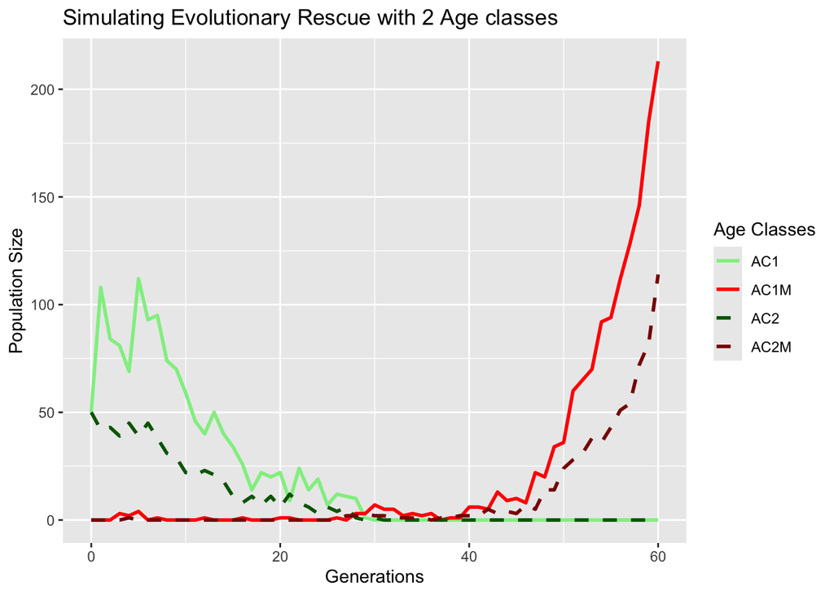

```r
# libraries needed to plot the population trajectory
library(ggplot2)
library(dplyr)
library(tidyr)

# define the parameters under which we want to simulate the population trajectory
N_j0 <- 50
N_a0 <- 50
N_j0M <- 0
N_a0M <- 0
R_a <- 2
R_aM <- 2.5
S_j <- 0.2
S_jM <- 0.3
S_a <- 0.5
S_aM <- 0.5
mu <- 0.01
t_max <- 1000


# having the simulation set as a variable
sim_data <- simulate_pop(N_j0, N_a0,N_j0M, N_a0M, R_a, R_aM, S_j, S_jM, S_a, S_aM, mu, t_max)

#Convert matrix to Dataframe to help analysis
df <- as.data.frame(sim_data)

# these steps were generated using ai help: The rownames are the Generation numbers. Let's make them a proper column.
df$Generation <- as.numeric(rownames(df))

# Reshape from Wide to Long format for ggplot
# This creates a column "Age_Class" (AC1, AC2, etc.) and "Population_Size".

#pivot_longer syntaxc first define what data you are looking at. here we are looking at df, our data frame. cols defines which columns to convert into the long format. we want to convert our Age class collumns into long format. names_to defines what the new column name should be.

df_long <- pivot_longer(
  df,
  cols = c("AC1", "AC2", "AC1M", "AC2M"),
  names_to = "Age_Class",
  values_to = "Population_Size"
)

ggplot(df_long, aes(x = Generation, y = Population_Size, color = Age_Class, linetype = Age_Class)) +
  geom_line(linewidth = 1) +
  scale_color_manual(values = c(
    "AC1" = "lightgreen",
    "AC2" = "darkgreen",
    "AC1M" = "red",
    "AC2M" = "darkred")) +
  labs(title = "Simulating Evolutionary Rescue with 2 Age classes", x = "Generations", y = "Population Size", color = "Age Classes", linetype = "Age Classes")+
  scale_linetype_manual(values = c(
    "AC1" = 1,
    "AC1M" = 1,
    "AC2" = 2,
    "AC2M" = 2))
```

## Plotting Comparing the effect of increasing Juvenile Survival rates vs increasing Adults survival rates on Evolutionary rescue.

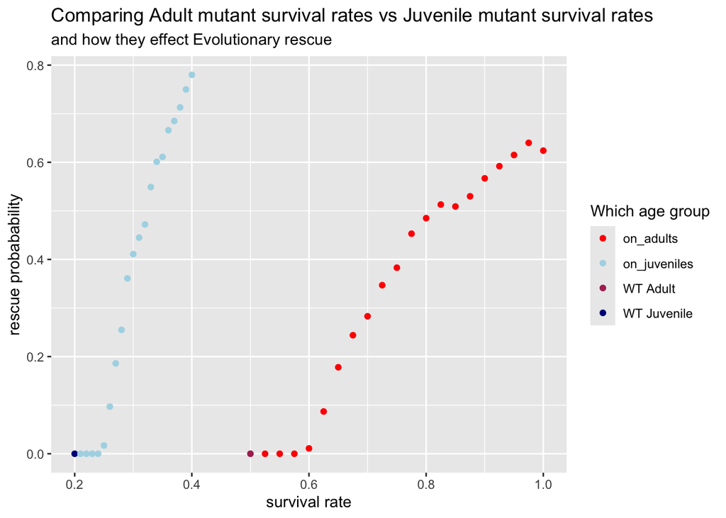

Fig. 2: Evolutionary rescue probabilities across varying survival rates. Parameters: N_j0=50, N_a0=50, N_j0M=0, N_a0M=0, R_a=2, R_aM=2, S_j=0.2, S_a=0.5, mu=0.01, t_max=1000, 1000 replicates.

```r
library(ggplot2)
library(gghighlight)
library(dplyr)
library(tidyr)

# Daten laden, sodass das Leerzeichen in "rescue prob." nicht überschrieben wird
plot_table <- read.csv("Data/plot_table.csv", check.names = FALSE)

plot_table_survcompare <- na.omit(as.data.frame(plot_table))
plot_table_survcompare$S_absolute <- as.numeric(plot_table_survcompare$S_absolute)
plot_table_survcompare$`rescue prob.` <- as.numeric(plot_table_survcompare$`rescue prob.`)

Plot_Survcompare <- ggplot(plot_table_survcompare, aes(
  x = S_absolute,
  y = `rescue prob.`,
  color = ifelse(!is.na(`rescue prob.`) & ac_s == "on_juveniles" & S_absolute == min(S_absolute[ac_s == "on_juveniles" & !is.na(`rescue prob.`)]), "WT Juvenile",
                 ifelse(!is.na(`rescue prob.`) & ac_s == "on_adults" & S_absolute == min(S_absolute[ac_s == "on_adults" & !is.na(`rescue prob.`)]), "WT Adult",
                        ac_s))
)) +
  geom_point() +
  labs(
    x = "survival rate",
    y = "rescue probabability",
    title = "Comparing Adult mutant survival rates vs Juvenile mutant survival rates",
    subtitle = "and how they effect Evolutionary rescue",
    color = "Which age group"
  ) +
  scale_color_manual(values = c(
    "on_adults" = "red",
    "on_juveniles" = "lightblue",
    "WT Juvenile" = "darkblue",
    "WT Adult" = "maroon"
  ))

print(Plot_Survcompare)
```

## Plotting the effect of increasing Reproduction Rate or Increasing survival rate on Evolutionary rescue

We then construct a heatmap of rescue probabilities overlaid with analytical growth rate isoclines ($\lambda = 1.0, 1.05, 1.10$). This allows us to observe whether evolutionary rescue is strictly determined by the asymptotic growth rate $\lambda$, or if partitioning fitness gains into reproduction versus survival creates distinct demographic trajectories under stochasticity.

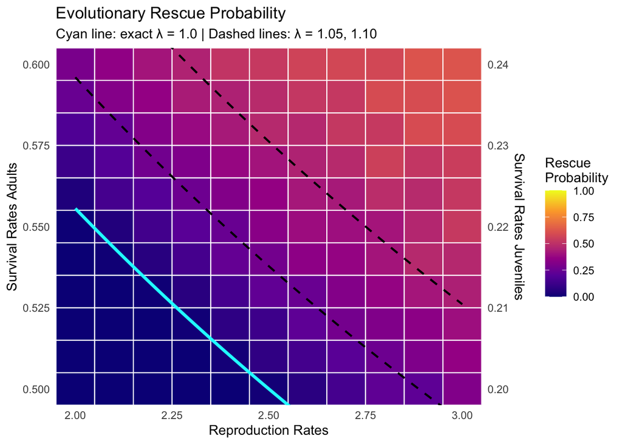

```r
# do the plots for the analysis of changed R vs.changed S. Heat Map
library(ggplot2)

summary_table <- read.csv("Data/summary_table.csv")

# 1. Format the data frame
# (Assuming your table now has these 5 columns based on your partner's updates)
heatmap_df <- as.data.frame(summary_table)
colnames(heatmap_df) <- c("rescue_prob", "Current_R", "Current_S_Adults", "Current_S_Juveniles")

# Ensure all columns are numeric so the plot axes are continuous, not categorical
heatmap_df[] <- lapply(heatmap_df, as.numeric)

# 2. Define the exact mathematical function for the isocline
# This solves the Leslie matrix characteristic equation for Adult Survival (y) based on Reproduction (x)
exact_isocline <- function(x, target_lambda, wt_S_j, wt_S_a) {
  (target_lambda^2) / (target_lambda + x * (wt_S_j / wt_S_a))
}

# 3. Build the heatmap with exact isoclines
ggplot(heatmap_df, aes(x = Current_R, y = Current_S_Adults)) +
  # Heatmap tiles
  geom_tile(aes(fill = rescue_prob), color = "white", linewidth = 0.4) +

  # Exact isocline for lambda = 1.0 (The critical deterministic survival threshold)
  stat_function(
    fun = exact_isocline,
    args = list(target_lambda = 1.0, wt_S_j = S_j, wt_S_a = S_a),
    color = "cyan", linewidth = 1.2
  ) +

  # Exact isocline for lambda = 1.05
  stat_function(
    fun = exact_isocline,
    args = list(target_lambda = 1.05, wt_S_j = S_j, wt_S_a = S_a),
    color = "black", linetype = "dashed", linewidth = 0.8
  ) +

  # Exact isocline for lambda = 1.10
  stat_function(
    fun = exact_isocline,
    args = list(target_lambda = 1.10, wt_S_j = S_j, wt_S_a = S_a),
    color = "black", linetype = "dashed", linewidth = 0.8
  ) +

  # Option B: Add secondary Y-axis for Juvenile Survival Rate
  scale_y_continuous(
    sec.axis = sec_axis(~ . * (S_j / S_a), name = "Survival Rates Juveniles")
  ) +

  scale_fill_viridis_c(
    limits = c(0, 1),
    option = "plasma",
    name = "Rescue\nProbability"
  ) +

  # Lock the plot boundaries to the edges of your simulated heatmap data
  coord_cartesian(
    xlim = range(heatmap_df$Current_R),
    ylim = range(heatmap_df$Current_S_Adults)
  ) +

  labs(
    title = "Evolutionary Rescue Probability",
    subtitle = "Cyan line: exact \u03BB = 1.0 | Dashed lines: \u03BB = 1.05, 1.10",
    x = "Reproduction Rates",
    y = "Survival Rates Adults"
  ) +
  theme_minimal() +
  theme(panel.grid = element_blank())
```

The gradient shows the rescue probability for the whole population. The lighter the color shows a higher rescue probability.

We See a gradual increase when moving along both axis. The color gradient seems more patchy in the top right corner compared to the bottom left corner.

# Discussion

Plot 1.

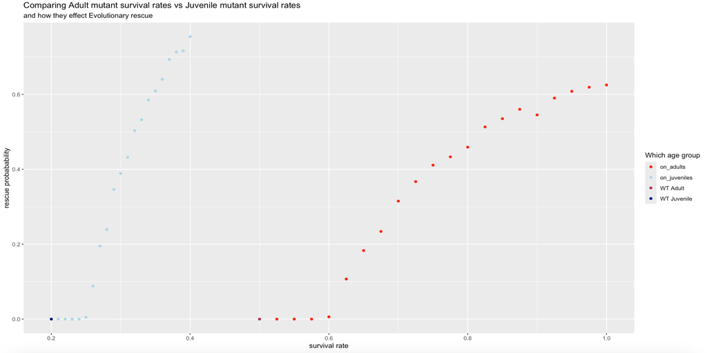

Our predicitons varried for our first question of wether mutant Adult Survival rates or mutant juvenile survival rates had a more substantial effect on increasing evolutionary rescue probability. predicted that the the survival probabilites would be greater if you increased the survival rates of the juveniles.

We are unsure if the observed Steeper curve when increasing juvenile survivalbility is someting we can draw conclusions on. This curve will naturally be steeper since the steps taken when increasing the survival rate depend on the starting “WT” survival rates. Since we use a multiplication and do not iterate over fixed value. This means that for example the first increase in survival rate for juveniles is $0.2 * 1.05 = 0.21$ where as the first step when increasing the adult survival rates is $0.5 * 1.05 = 0.525$ . The steps in the juvenile curve are smaller on the x axis. Although we are increasing both values by the same factor the steps at which they increase are different. This can lead to a “skew” in our results.

A very interesting data point is the final data point in the on_adults graph. This data point has a mutated survival rate double that of the WT and since our WT population has an adult survival rate of 0.5 this means in this mutated population the adult survival rate is 1.0 meaning ALL adults survive to become adults again. It is interesting to see that despite this case the rescue probability still only lies around 0.625 so 60% of the chance to be rescued under these conditions. As the 100% survival rate is biologically rather unrealistic we can look at 1 data point before that, where the adult survival rate lies at 0.975. Under these simulated parameters the population “only” has rescue probability of around 0.619 again around that 60% mark. These data points are interesting from a conservation perspective.

Imagine a hypothetical scenario based on our simulations. If you had a hypothetical population where a mutant adult has been introduced which has a survival rate of 0.975 to survive. You as a conervationist are using the survival rates of adults as a measure to deem if a population can be considered rescued or not. According to our model you would observe the vast majority of your Adult population surviving and may be tempted to not bother with any consevation methods that would aid either the juveniles sruvival rates or the reproduciton of the adults. In the case where you would maybe still have the resources to keep aiding the population you may decide not to use them as the metric you use to deem a population stable is simply the survival rates of the adults, but in the long run there is still a 40% chance that this population may still go extinct. It would therefore still be important if you had the resources to consider aiding other parts of the population to increase the chances of survival even more.

It is important to not a “doubling” of survival rates is biologically unrealistic. A singular mutation would likely not be able to have such a large effect on the survival rates of juvenile individuals.

Plot 2.

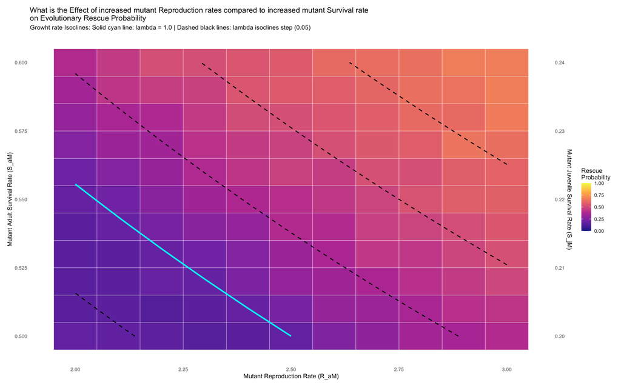

The goal of our heat map was to see whether increasing either reproduction rate or survival rate had a greater effect on the rescue probability. Compared to our first analysis, here we ask the question of whether the function of the mutation / where the mutation acts matters.

A heat map is helpful as it allows us to compare low reproduction rates with high survival rates, high reproduction rates with low survival rates etc. We expected that a mutation of one function may be able to compensate another, for example if you have an introduced mutation that only minimally effects the survival rate if having a mutation that greatly effects the reproduction rate can compensate this minimal effect. The other interesting data we can observe in our graph is how mutant reproduction rates effect the population as before in our first analysis we only changed the survival rates and our mutant population had the same reproduction rates as the wild type.

What we can conclude from the general gradient trend in our graph is a somewhat linear relationship. As mutant reproduction rates increase and mutated survival rates increase, the survival probability increases with it. This could indicate that in our biological system having an increased mutant reproduction rate has a similar effect on evolutionary rescue as an increased mutant survival rate.

Neither the survival rate nor the reproduction rate seems to have a “greater” effect. A conclusion you could draw from this is that accumulating beneficial mutaitons that act on different functions is more beneficial for evolutionary rescue than if a mutation arises with a strong effect on one function.

The isoclines help us with this conclusion as all the rectangles along an isocline have the same overall growth rate. if we follow an isocline we see that the differences in color are very minimal. If it were the case that Reproduction rate had a more substantial effect than if you were to follow an isocline (say the dashed isocline above the cyan isocline) then as you move along towards the bottom right corner you should see the colors become brighter. In our simulations we do not see any trend like this but instead see a more constant color gradient.

- points still to be discussed

  is there more “high rescue prob” squares in one of the axis? what does this say about our model? what could changing the model do / adding more age classes. more of a discussion on what could be done in the future.

# Stuff that we are not shure about yet if and how to include in the report

### Lambda calculations that we needed for the inprecise method of adding the isoclines

```r
summary_table$lambda_mutant <- 0
add_Mut_lambda <- function(summary_table){
  for (i in 1:nrow(summary_table)) {
    current_l_matrix_Mut <- matrix(c(
      0, summary_table[i,"Reproduction rate"],
      summary_table[i,"Current_S_Juveniles"], summary_table[i,"Current_S_Adults"]
    ), nrow = 2, byrow = TRUE)

    all_eigen <- eigen(current_l_matrix_Mut)
    current_growth_rate_mut <- max(Re(all_eigen$values))
    summary_table[i,"lambda_mutant"] <- current_growth_rate_mut
  }
  return(summary_table)
}

summary_table <- add_Mut_lambda(summary_table)

current_l_matrix_Mut <- matrix(c(
  0, summary_table[1,"Reproduction rate"],
  summary_table[1,"Current_S_Juveniles"], summary_table[1,"Current_S_Adults"]
), nrow = 2, byrow = TRUE)
summary_table[1,"Reproduction rate"]
summary_table[1,"Current_S_Juveniles"]
summary_table[1,"Current_S_Adults"]
current_l_matrix_Mut
```

### Not so precise method of doing the isoclines on the heat map

```r
library(ggplot2)

summary_table <- read.csv("Data/summary_table.csv")

# 1. Prepare heatmap_df (from your R vs S simulation chunk)
heatmap_df <- as.data.frame(summary_table)
colnames(heatmap_df) <- c("rescue_prob", "Current_R", "Current_S_Adults")
heatmap_df$rescue_prob      <- as.numeric(heatmap_df$rescue_prob)
heatmap_df$Current_R        <- as.numeric(heatmap_df$Current_R)
heatmap_df$Current_S_Adults <- as.numeric(heatmap_df$Current_S_Adults)

# Reconstruct Current_S_Juveniles (since both scale with surv_val, S_jM = S_aM * (S_j / S_a))
heatmap_df$Current_S_Juveniles <- heatmap_df$Current_S_Adults * (S_j / S_a)

# Calculate Mutant Lambda directly for every row in the table
heatmap_df$lambda <- (heatmap_df$Current_S_Adults +
                        sqrt(heatmap_df$Current_S_Adults^2 + 4 * heatmap_df$Current_R * heatmap_df$Current_S_Juveniles)) / 2

# 2. Plot Heatmap + Lambda Isoclines
ggplot(heatmap_df, aes(x = Current_R, y = Current_S_Adults)) +
  # Heatmap tiles (using continuous x and y!)
  geom_tile(aes(fill = rescue_prob), color = "white", linewidth = 0.2) +

  # Isoclines for lambda = 1.0, 1.05, 1.1, 1.15, 1.2
  geom_contour(
    aes(z = lambda),
    breaks = seq(0.95, 1.3, by = 0.05),
    color = "black",
    linewidth = 0.8,
    linetype = "dashed"
  ) +

  # Highlight the critical lambda = 1 threshold in solid white/black
  geom_contour(
    aes(z = lambda),
    breaks = 1.0,
    color = "cyan",
    linewidth = 1.2
  ) +

  # Show Juvenile Survival on the right Y-axis
  scale_y_continuous(
    name = "Mutant Adult Survival Rate (S_aM)",
    sec.axis = sec_axis(~ . * (S_j / S_a), name = "Mutant Juvenile Survival Rate (S_jM)")
  ) +
  scale_fill_viridis_c(
    limits = c(0, 1),
    option = "plasma",
    name = "Rescue\nProbability"
  ) +
  labs(
    title = "What is the Effect of increased mutant Reproduction rates compared to increased mutant Survival rate
on Evolutionary Rescue Probability",
    subtitle = "Growht rate Isoclines: Solid cyan line: lambda = 1.0 | Dashed black lines: lambda isoclines step (0.05)",
    x = "Mutant Reproduction Rate (R_aM)"
  ) +
  theme_minimal() +
  theme(panel.grid = element_blank())
```

### Old plotting chunk

```r
library(ggplot2)
library(gghighlight)
library(dplyr)
library(tidyr)

plot_table <- read.csv("Data/plot_table.csv")

plot_table_survcompare <- as.data.frame(plot_table) #converting the table to a data frame
plot_table_survcompare$S_absolute <- as.numeric(plot_table_survcompare$S_absolute)
#values treated as numeric to allow for ggplot to recognize them
plot_table_survcompare$rescue.prob. <- as.numeric((plot_table_survcompare$rescue.prob.))


Plot_Survcompare <- ggplot(plot_table_survcompare, aes(x = S_absolute , y = rescue.prob.,
                                                       color = ifelse(!is.na(rescue.prob.) & ac_s == "on_juveniles" & S_absolute == min(S_absolute[ac_s == "on_juveniles" & !is.na(rescue.prob.)]), "WT Juvenile", #marks the lowest data point for the on_juveniles, this is the data point for the wild type Juvenile
                                                                      ifelse(
                                                                        !is.na(`rescue.prob.`) & ac_s == "on_adults" & S_absolute == min(S_absolute[ac_s == "on_adults" & !is.na(`rescue.prob.")]), "WT Adult", #marks the lowest data point for the on_adults, this is the data point for the wild type Adult
        ac_s)))) +

  geom_point()+ #we use a scatter plot to plot our data
  labs(x = "survival rate", y = "rescue probabability", title = "Comparing Adult mutant survival rates vs Juvenile mutant survival rates", subtitle = "and how they effect Evolutionary rescue", color = "Which age group")+
  scale_color_manual(values = c("on_adults" = "red",
                     "on_juveniles" = "lightblue",
                     "WT Juvenile" = "darkblue",
                     "WT Adult" = "maroon" ))


print(Plot_Survcompare)


#ggsave(Plot_Survcompare,
       #filename = "Plot_Survcompare.pdf",
       #device = "pdf")
```

## matrix thing to keep the lambda constant

```r
# define column names of data table
colnames(data_table) <- c("repro_multiplier", "surv_multiplier", "min_gen", "min_size", "extinct")

# Convert to data frame
data_table_RvsS <- as.data.frame(data_table)

# show the first lines of the output
print((data_table_RvsS))


library(dplyr)
summary_table <- data_table_RvsS %>%
  group_by(repro_multiplier, surv_multiplier) %>%
  summarize(
    probability_survival = 1 - mean(extinct),
    avg_rescue_speed = mean(min_gen),
    avg_min_population = mean(min_size)
  )

print(summary_table)
```

```r
# 1. Define resident matrix
# define WT leslie matrix and get growth rate
  l_matrix_WT <- matrix(c(
    0, R_a,
    S_j, S_a
  ), nrow = 2, byrow = TRUE)

  all_eigen <- eigen(l_matrix_WT)
  growth_rate_WT <- max(Re(all_eigen$values))
  l_matrix_WT
  growth_rate_WT

# define Mut leslie matrix and getting growth rate
  R_aM <- 1.5 * R_a
  S_jM <- 1.2 * S_j
  S_aM <- 1.2 * S_a
  l_matrix_Mut <- matrix(c(
    0, R_aM,
    S_jM, S_aM
  ), nrow = 2, byrow = TRUE)

  all_eigen <- eigen(l_matrix_Mut)
  growth_rate_Mut <- max(Re(all_eigen$values))
  l_matrix_Mut
  growth_rate_Mut

# 2. Function to compute required reproduction multiplier (reproduction_advantage) for a given survival multiplier (survival_advantage)
  find_repro_multiplier <- function(survival_advantage, matrix, target_lambda) {
    F1 <- matrix[1, 1]
    F2 <- matrix[1, 2]
    P1 <- matrix[2, 1]
    P2 <- matrix[2, 2]

    num <- target_lambda^2 - survival_advantage * P2 * target_lambda
    den <- F1 * target_lambda - survival_advantage * (F1 * P2 - F2 * P1)

    return(num / den)
  }
```

## Testing the equation for the probability of evolutionary rescue through a new mutation

The Equation: $P_{new} = 1 - e^{-\frac{2N_0 u (s - r)}{r}}$

The parameters

- $P_{new}$ : Probability of Evolutionary Rescue
- $N_0$: Initial population size
- $u$: mutation rate
- $s$: selection coefficient (advantage of mutant relative to WT)
- $r$: decay rate (1-initial growth rate)

### How the parameters translate to our model

- Selection coefficient ($s$): This would be the lambda of the Mutant Leslie Matrix minus the lambda of the WT-Leslie Matrix.
- decay rate ($r$): 1 - The lambda of the WT-Leslie Matrix
- The other parameters are unchanged in our model and we keep them as they are.

### How to test the equation

The same lambda can be achieved with different matrices. So in our case with different values for the Reproduction- and Survival rates. To really know if the rescue probability of the population in our model can be explained only by the lambda + the other parameters on the right side of the equation we would need to test for different combinations of Reproduction- / Survival-rates. For that we could use the code used above to quantify the importance of a higher reproduction in the mutants vs. a higher survival.

### Actual coding

#### Creating “summary_table”

The initial code gives a table called “summary_table”, which contains:

- **Rescue Probability**
- **repro_multiplie**r: A number higher than 1 with which the reproduction rate of the WT-Adults is multiplied to get the reproduction rate of the Mutant-Adults. The initial reproduction rate was 2.
- **surv_multiplier**: A number higher than 1 with which the survival rates of the WT-Adults and Juveniles is multiplied to get the survival rates of the Mutant-Adults and Juveniles. The initial survival rates were 0.2 for the juveniles and 0.5 for the adults.

#### Getting the corresponding selection coefficient + initial growth rate

For the equation i need to calculate the selection coefficient + the initial growth rate of the population. These can be derived from the parameters “$R_a$”, “$S_j$”,, “$S_a$”, “repro_val” and “surv_val”.

#### Calculating the “$P_{new}$” with the equation: $P_{new} = 1 - e^{-\frac{2N_0 u (s - r)}{r}}$ for each row in summary_table

#### Deleting all rows where s is not > than r

```r
# --- 1. BASE PARAMETERS ---
N_0 <- 100
N_j0 <- 50
N_a0 <- 50
# N_j0 <- round(N_0 * stabile_verteilung[1])
# N_a0 <- round(N_0 * stabile_verteilung [2])
N_j0M <- 0
N_a0M <- 0
R_a <- 2
S_j <- 0.17
S_a <- 0.3
mu <- 0.01
t_max <- 1000



# Simulation repetitions
no_replicates <- 100

#data table initializing
data_table <- c()

# loop over reproduction selection
for (repro_val in seq(1,1.5,0.05)) {

  # loop over survival selection
  for (surv_val in seq(1, 2, 0.1)) {

    # Calculate modified rates based on current loop values
    current_R_aM <- R_a * repro_val
    current_S_aM <- S_a * surv_val
    current_S_jM <- S_j * surv_val

    # reset counter for replicates
    i <- 1

    repeat {
      # run the simulation once with the modified parameters
      one_run <- simulate_pop(N_j0, N_a0, N_j0M, N_a0M,
                              R_a, current_R_aM,
                              S_j, current_S_jM,
                              S_a, current_S_aM,
                              mu, t_max)

      # determine total population sizes
      total_size <- one_run[,1] + one_run[,2] + one_run[,3] + one_run[,4]

      # determine minimum population size
      min_size <- min(total_size)

      # determine (first) generation at which this population size occurred
      min_gen <- as.numeric(which(total_size == min_size)[1])

      # enter the data into the table
      data_table <- rbind(data_table, c(repro_val, surv_val, min_gen, min_size))

      # stop the repeated computation after no_replicates times
      if (i >= no_replicates) break

      # increase counter by one
      i <- i + 1
    }
  }
}

# define column names of data table
colnames(data_table) <- c("repro_multiplier", "surv_multiplier", "min_gen", "min_size")

# Convert to data frame
data_table_analysis <- as.data.frame(data_table)
# Add "rescued" column
data_table_analysis$rescued <- data_table_analysis$min_size != 0



summary_table <- c()
for(x in unique(data_table_analysis$repro_multiplier)){
  for(s in unique(data_table_analysis$surv_multiplier)){
    data_table_filter <- data_table_analysis[data_table_analysis$repro_multiplier == x & data_table_analysis$surv_multiplier == s,]
    summary_table <- rbind(summary_table, c(mean(data_table_filter$rescued), x, s))
  }
}

colnames(summary_table) <- c("resque probability", "repro_multiplier", "surv_multiplier")
summary_table <- as.data.frame(summary_table)
# the initial r-value is the same for all
  # define WT leslie matrix, get growth rate and define "r"
  l_matrix_WT <- matrix(c(
    0, R_a,
    S_j, S_a
  ), nrow = 2, byrow = TRUE)
  # Eigenanalyse berechnen
  ev <- eigen(l_matrix_WT)
  all_eigen <- eigen(l_matrix_WT)
  # 1. Dominanter Eigenwert (Wachstumsrate lambda)
  # Der betragsgrößte Eigenwert steht an Position 1
  growth_rate_WT <- max(Re(ev$values[1]))
  r <-  1 - growth_rate_WT

  # 2. Rechter Eigenvektor (stabile Altersverteilung)
  # Imaginärteil verwerfen und auf Summe = 1 normieren
  w <- Re(ev$vectors[, 1])
  stabile_verteilung <- w / sum(w)


# here i want to add the corresponding s-values to the summary_table
  # Calculate difference in days, then convert to approximate years
  # make function to generally get the selection_coefficient
    # first create a new column for the summary_table
    summary_table$selection_coefficient <- 0

    get_s <- function(R_a, S_j, S_a, summary_table, r, growth_rate_WT){
      selection_coefficients <- c()
      for (i in 1:nrow(summary_table)) {
        #make the current matrix and calculate the current_mut_r
        R_aM <- R_a * summary_table[i, "repro_multiplier"]
        S_jM <- S_j * summary_table[i, "surv_multiplier"]
        S_aM <- S_a * summary_table[i, "surv_multiplier"]
        current_l_matrix_Mut <- matrix(c(
          0, R_aM,
          S_jM, S_aM
        ), nrow = 2, byrow = TRUE)

        all_eigen <- eigen(current_l_matrix_Mut)
        current_mut_r <- max(Re(all_eigen$values))

        current_selection_coefficient <- current_mut_r - growth_rate_WT

        summary_table[i, "selection_coefficient"] <- current_selection_coefficient
        print(current_selection_coefficient)

      }
      return(summary_table)
    }

    summary_table <- get_s(R_a, S_j, S_a, summary_table, r, growth_rate_WT)

# now i wan't to calculate the P_new and add it to the summary_table
    summary_table$rescue_probability_equation <- 0
    N_0 <- N_a0 + N_a0M + N_j0 + N_j0M
    add_p_new <- function(N_0, mu, r, summary_table){
      for (i in 1:nrow(summary_table)){
        s <- summary_table[i, "selection_coefficient"]
        P_new <- 1 - exp(-(2*N_0*mu*(s-r))/(r))
        summary_table[i, "rescue_probability_equation"] <- P_new
      }
     return(summary_table)
    }

  summary_table <- add_p_new(N_0, mu, r, summary_table)

  # 1. Calculate mutant lambda (growth_rate_WT + s)
  summary_table$lambda_mutant <- growth_rate_WT + summary_table$selection_coefficient

  # 2. Filter out negative estimated rescue probabilities and reshape for plotting
  plot_data <- summary_table %>%
    filter(rescue_probability_equation >= 0) %>%
    rename(Simulated = `resque probability`, Formula = rescue_probability_equation) %>%
    pivot_longer(
      cols = c(Simulated, Formula),
      names_to = "Source",
      values_to = "Rescue_Probability"
    )

  # 3. Create the plot
  ggplot(plot_data, aes(x = lambda_mutant, y = Rescue_Probability, color = Source)) +
    geom_point(alpha = 0.7, size = 2) +
    geom_smooth(se = FALSE, method = "loess", span = 0.8) +
    theme_minimal() +
    labs(
      title = "Evolutionary Rescue Probability vs. Mutant Growth Rate",
      x = expression(paste("Mutant Growth Rate (", lambda[mut], ")")),
      y = "Rescue Probability",
      color = "Type"
    ) +
    scale_color_manual(values = c("Simulated" = "steelblue", "Formula" = "darkorange")) +
    ylim(0, 1)
```

## Sanity checking

```r
# --- 1. BASE PARAMETERS ---
N_0 <- 100
N_j0 <- round(N_0 * stabile_verteilung[1])
N_a0 <- round(N_0 * stabile_verteilung [2])
N_j0M <- 0
N_a0M <- 0
R_a <- 0.9
S_j <- 1
S_a <- 0
mu <- 0.01
t_max <- 1000



# Simulation repetitions
no_replicates <- 100

#data table initializing
data_table <- c()

# loop over reproduction selection
for (repro_val in seq(1,1.5,0.05)) {

  # loop over survival selection
  for (surv_val in seq(1, 1, 1)) {

    # Calculate modified rates based on current loop values
    current_R_aM <- R_a * repro_val
    current_S_aM <- S_a * surv_val
    current_S_jM <- S_j * surv_val

    # reset counter for replicates
    i <- 1

    repeat {
      # run the simulation once with the modified parameters
      one_run <- simulate_pop(N_j0, N_a0, N_j0M, N_a0M,
                              R_a, current_R_aM,
                              S_j, current_S_jM,
                              S_a, current_S_aM,
                              mu, t_max)

      # determine total population sizes
      total_size <- one_run[,1] + one_run[,2] + one_run[,3] + one_run[,4]

      # determine minimum population size
      min_size <- min(total_size)

      # determine (first) generation at which this population size occurred
      min_gen <- as.numeric(which(total_size == min_size)[1])

      # enter the data into the table
      data_table <- rbind(data_table, c(repro_val, surv_val, min_gen, min_size))

      # stop the repeated computation after no_replicates times
      if (i >= no_replicates) break

      # increase counter by one
      i <- i + 1
    }
  }
}

# define column names of data table
colnames(data_table) <- c("repro_multiplier", "surv_multiplier", "min_gen", "min_size")

# Convert to data frame
data_table_analysis <- as.data.frame(data_table)
# Add "rescued" column
data_table_analysis$rescued <- data_table_analysis$min_size != 0



summary_table <- c()
for(x in unique(data_table_analysis$repro_multiplier)){
  for(s in unique(data_table_analysis$surv_multiplier)){
    data_table_filter <- data_table_analysis[data_table_analysis$repro_multiplier == x & data_table_analysis$surv_multiplier == s,]
    summary_table <- rbind(summary_table, c(mean(data_table_filter$rescued), x, s))
  }
}

colnames(summary_table) <- c("resque probability", "repro_multiplier", "surv_multiplier")
summary_table <- as.data.frame(summary_table)
# the initial r-value is the same for all
# define WT leslie matrix, get growth rate and define "r"
l_matrix_WT <- matrix(c(
  0, R_a,
  S_j, S_a
), nrow = 2, byrow = TRUE)
# Eigenanalyse berechnen
ev <- eigen(l_matrix_WT)
all_eigen <- eigen(l_matrix_WT)
# 1. Dominanter Eigenwert (Wachstumsrate lambda)
# Der betragsgrößte Eigenwert steht an Position 1
growth_rate_WT <- max(Re(ev$values[1]))
r <-  1 - growth_rate_WT

# 2. Rechter Eigenvektor (stabile Altersverteilung)
# Imaginärteil verwerfen und auf Summe = 1 normieren
w <- Re(ev$vectors[, 1])
stabile_verteilung <- w / sum(w)


# here i want to add the corresponding s-values to the summary_table
# Calculate difference in days, then convert to approximate years
# make function to generally get the selection_coefficient
# first create a new column for the summary_table
summary_table$selection_coefficient <- 0

get_s <- function(R_a, S_j, S_a, summary_table, r, growth_rate_WT){
  selection_coefficients <- c()
  for (i in 1:nrow(summary_table)) {
    #make the current matrix and calculate the current_mut_r
    R_aM <- R_a * summary_table[i, "repro_multiplier"]
    S_jM <- S_j * summary_table[i, "surv_multiplier"]
    S_aM <- S_a * summary_table[i, "surv_multiplier"]
    current_l_matrix_Mut <- matrix(c(
      0, R_aM,
      S_jM, S_aM
    ), nrow = 2, byrow = TRUE)

    all_eigen <- eigen(current_l_matrix_Mut)
    current_mut_r <- max(Re(all_eigen$values))

    current_selection_coefficient <- current_mut_r - growth_rate_WT

    summary_table[i, "selection_coefficient"] <- current_selection_coefficient
    print(current_selection_coefficient)

  }
  return(summary_table)
}

summary_table <- get_s(R_a, S_j, S_a, summary_table, r, growth_rate_WT)

# now i wan't to calculate the P_new and add it to the summary_table
summary_table$rescue_probability_equation <- 0
N_0 <- N_a0 + N_a0M + N_j0 + N_j0M
add_p_new <- function(N_0, mu, r, summary_table){
  for (i in 1:nrow(summary_table)){
    s <- summary_table[i, "selection_coefficient"]
    P_new <- 1 - exp(-(2*N_0*mu*(s-r))/(r))
    summary_table[i, "rescue_probability_equation"] <- P_new
  }
  return(summary_table)
}

summary_table <- add_p_new(N_0, mu, r, summary_table)

# 1. Calculate mutant lambda (growth_rate_WT + s)
summary_table$lambda_mutant <- growth_rate_WT + summary_table$selection_coefficient

# 2. Filter out negative estimated rescue probabilities and reshape for plotting
plot_data <- summary_table %>%
  filter(rescue_probability_equation >= 0) %>%
  rename(Simulated = `resque probability`, Formula = rescue_probability_equation) %>%
  pivot_longer(
    cols = c(Simulated, Formula),
    names_to = "Source",
    values_to = "Rescue_Probability"
  )

# 3. Create the plot
ggplot(plot_data, aes(x = lambda_mutant, y = Rescue_Probability, color = Source)) +
  geom_point(alpha = 0.7, size = 2) +
  geom_smooth(se = FALSE, method = "loess", span = 0.8) +
  theme_minimal() +
  labs(
    title = "Evolutionary Rescue Probability vs. Mutant Growth Rate",
    x = expression(paste("Mutant Growth Rate (", lambda[mut], ")")),
    y = "Rescue Probability",
    color = "Type"
  ) +
  scale_color_manual(values = c("Simulated" = "steelblue", "Formula" = "darkorange")) +
  ylim(0, 1)
```